# Data Mining Project 1 part III

Karolina Kwasiborska, Tomasz Zaremba, Ziad Al Bkhetan

25 Nov 2015

# Introduction

in this project we will use different classifiers  
1: k-nearest neighbors  
2: SVM  
3: Decision Tree  
4: Random Forests  
5: Naive Bays  
6: LDA  
7: QDA  
8: Stochastic Gradient Boosting (gbm)  
9: Boosted Logistic Regression  
10: Neural Network  
11: Partial Least Squares (kernelpls)  
12: Robust Regularized Linear Discriminant Analysis (rrlda)

then we will evaluate all these classifiers using:  
1: ROC Curve  
2: Area Under ROC curve  
3: Accurecy using confusion Matrix

# Data Loading And Preparation

Starting with data loading into the variable australianDataSet using R script  
Data Link is http://archive.ics.uci.edu/ml/machine-learning-databases/statlog/australian/australian.dat  
Target attribute “A15” is categorized using factor function  
The dataset is normalized for K-nearest neighbors classifier  
The dataset is categorized into equal size subranges for Naive Bays classifier  
and also in this phase we will divide the dataset into two different sets the first one for classifier training while the second is for the classifier testing.  
* partion percentage is 80:20  
* target attribute to maintain good distribution “A15”

```r
library(mlbench)
library(caret)
library(randomForest)
library(rpart)
library(e1071)
library(MASS)
library(gbm)
library(Hmisc)
library(ROCR)
library(pls)
library(rrcov)
library(klaR)

australianDataSet = read.table("D:\\MSc Computer science and informatics\\3rd semester\\Data Mining - Advances\\Project1\\australian.dat",
        sep=" ",header=F,col.names=c("A1", "A2", "A3", "A4",
                "A5","A6", "A7", "A8", "A9","A10",
                "A11", "A12", "A13","A14", "A15"),
        fill=FALSE,strip.white=T)

originalaustralianDataSet <-australianDataSet
australianDataSet$A15 <- factor(ifelse(australianDataSet$A15 == 0, "One", "Zero"))
#partitioning
indxTrain <- createDataPartition(y = australianDataSet$A15, p = 0.8)
australianDataSetTrain<- australianDataSet[indxTrain$Resample1,]
australianDataSetTest <- australianDataSet[-indxTrain$Resample1,]
# Data normalization
normalize <- function(x) {
  scale(x)
}

australianDataSetNormalized <- as.data.frame(lapply(australianDataSet[, 1:14], normalize))
australianDataSetNormalized$A15 <-australianDataSet$A15
# Training and Testing Datasets
indxTrain <- createDataPartition(y = australianDataSetNormalized$A15, p = 0.8)
australianDataSetNormalizedTrain<- australianDataSetNormalized[indxTrain$Resample1,]
australianDataSetNormalizedTest <- australianDataSetNormalized[-indxTrain$Resample1,]

# Data Categorization
aust_equal_size <- originalaustralianDataSet
for (i in c(2, 3, 4, 5, 6, 7, 10, 12, 13, 14)) {
  aust_equal_size[,i]<- cut2(australianDataSet[,i], g=3)
}
aust_equal_size$A15 <- factor(ifelse(aust_equal_size$A15 == 0, "One", "Zero"))
aust_equal_size$A1 <-factor(aust_equal_size$A1)
aust_equal_size$A8 <-factor(aust_equal_size$A8)
aust_equal_size$A9 <-factor(aust_equal_size$A9)
aust_equal_size$A11 <-factor(aust_equal_size$A11)
# Partitioning
indxTrain <- createDataPartition(y = aust_equal_size$A15, p = 0.8)
aust_equal_sizeTrain<- aust_equal_size[indxTrain$Resample1,]
aust_equal_sizeTest <- aust_equal_size[-indxTrain$Resample1,]
```

# Features Importance

Using Random forest library, we can find the important variables which describe the dataset, then we will choose the suitable model to build our classifiers  
we will use A15 ~ A8 + A14 + A10 + A5 +A7 + A13 + A9.

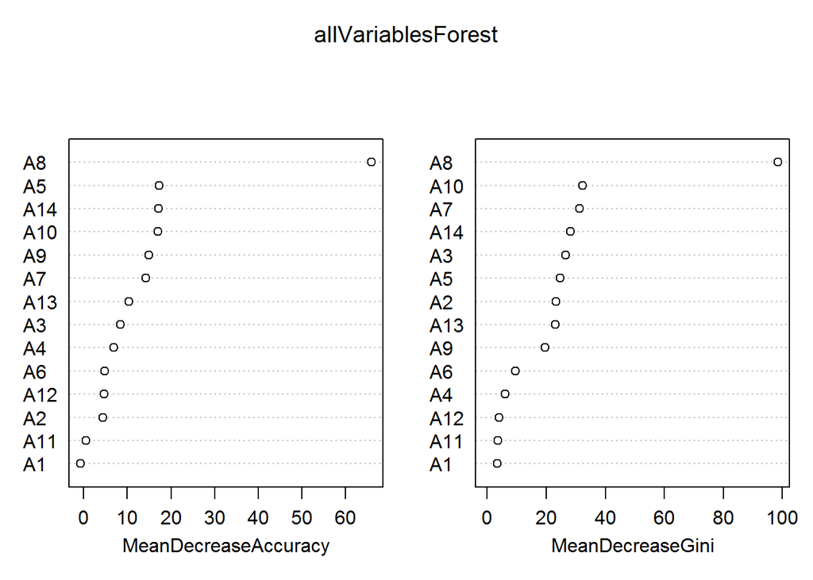

```r
allVariablesForest <- randomForest(A15 ~ ., data = australianDataSet, importance = TRUE, na.action = na.omit)
varImpPlot(allVariablesForest)
```

# Classifiers Training And Testing

We have created a daynamic scripts to apply all classifiers on the training dataset then test the classifiers on the testing dataset, if you want to use other classifiers, just you need to put their names in the classifiers list “but they shouldn’t need any exeptional workflow”.

```r
# prepare training scheme
control <- trainControl(method="repeatedcv", number=10, repeats=3, classProbs=T, savePredictions = T)
classifiersCount = 12
counter = 1
outMat<-matrix(list(), nrow=classifiersCount, ncol=2)
conf_mat <-matrix(list(), nrow=classifiersCount, ncol=1)
rocMat<-matrix(list(), nrow=classifiersCount, ncol=2)

for(classfierType in c('nb', 'rf', 'rpart', 'lda', 'qda', 'gbm', 'svmRadial', 'LogitBoost', 'knn', 'nnet', 'kernelpls', 'rrlda'))
{
  if(classfierType == 'knn')
  {
    trainDS <- australianDataSetNormalizedTrain
    testDS <- australianDataSetNormalizedTest
  }
  else if(classfierType == 'nb')
      {
        trainDS <- aust_equal_sizeTrain
        testDS  <- aust_equal_sizeTest
      } else
        {
          trainDS <- australianDataSetTrain
          testDS <- australianDataSetTest
        }

  currModel<- train(A15 ~ A8 + A14 + A10 + A5 +A7 + A13 + A9, data=trainDS, method=classfierType, trControl=control)
  predTab <- predict(currModel, testDS)
  outMat[[counter, 1]] <- table(true = testDS$A15, predicted = predTab)
  # Accuracy
  outMat[[counter, 2]] <- sum(diag(outMat[[counter, 1]])) / sum(outMat[[counter, 1]])
  # Confusion matrix
  conf_mat[[counter, 1]] <- confusionMatrix(predTab, testDS$A15)
  # ROC and AUC

  predTabPro <- predict(currModel, newdata=testDS, type="prob")[,2]
  pred <- prediction(predTabPro, testDS$A15)
  rocMat[[counter, 1]] <- performance(pred, "tpr", "fpr")
  # Area Under Curve
  rocMat[[counter, 2]] <- performance(pred,"auc")

  counter= counter + 1
}
```

# ROC (Receiver Operating Characteristics)

In this part, we will draw the ROC curves for all classifiers using the data from the previous script.

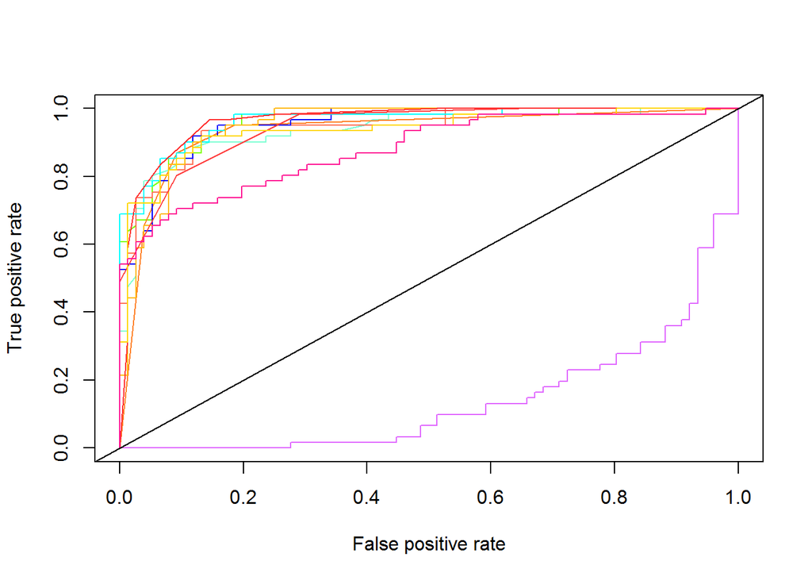

```r
colors <- c('aquamarine', 'chartreuse', 'chocolate1', 'coral1', 'blue', 'cyan', 'darkgoldenrod1', 'brown1', 'firebrick1', 'gold', 'deeppink', 'mediumorchid1', 'palegreen')

plot(rocMat[[1, 1]], col=colors[1])
for (counter in 2:classifiersCount)
{
  plot(rocMat[[counter, 1]], col=colors[counter], add=TRUE)
}
abline(a=0, b=1)
```

Legend:

```r
clas<-c("Naive Bays", "Random Forests", "Descion Tree", "LDA", "QDA", "GBM", "SVM", "LogitBoost", "KNN", "Neural Network", "Kernelpls", "rrlda")
colors <- c('aquamarine', 'chartreuse', 'chocolate1', 'coral1', 'blue', 'cyan', 'darkgoldenrod1', 'brown1', 'firebrick1', 'gold', 'deeppink', 'mediumorchid1', 'palegreen')

for(counter in 1:classifiersCount)
{
  print (paste("Classifier : " , clas[counter], " Color:", colors[counter], sep = "  "))
}
```

```
## [1] "Classifier :   Naive Bays   Color:  aquamarine"
## [1] "Classifier :   Random Forests   Color:  chartreuse"
## [1] "Classifier :   Descion Tree   Color:  chocolate1"
## [1] "Classifier :   LDA   Color:  coral1"
## [1] "Classifier :   QDA   Color:  blue"
## [1] "Classifier :   GBM   Color:  cyan"
## [1] "Classifier :   SVM   Color:  darkgoldenrod1"
## [1] "Classifier :   LogitBoost   Color:  brown1"
## [1] "Classifier :   KNN   Color:  firebrick1"
## [1] "Classifier :   Neural Network   Color:  gold"
## [1] "Classifier :   Kernelpls   Color:  deeppink"
## [1] "Classifier :   rrlda   Color:  mediumorchid1"
```

# Results

```r
vals <- rep(0.00, times = 24)
for(counter in 1:classifiersCount)
{
  vals[2 * counter - 1] = outMat[[counter, 2]]
  vals[2 * counter ] = rocMat[[counter, 2]]@y.values[[1]]
}

mesTab <- matrix(vals, ncol=2, nrow = 12, byrow = TRUE)
colnames(mesTab) <- c("Accuracy",  "AUC")
rownames(mesTab) <- c("Naive Bays", "Random Forests", "Descion Tree", "LDA", "QDA", "GBM", "SVM", "LogitBoost", "KNN", "Neural Network", "Kernelpls", "rrlda")
mesTab
```

```
##                 Accuracy       AUC
## Naive Bays     0.8832117 0.9362597
## Random Forests 0.8832117 0.9557808
## Descion Tree   0.8905109 0.9327006
## LDA            0.8832117 0.9449957
## QDA            0.8029197 0.9538395
## GBM            0.8905109 0.9628991
## SVM            0.8905109 0.9497412
## LogitBoost     0.8613139 0.9435936
## KNN            0.8978102 0.9634383
## Neural Network 0.8905109 0.9361519
## Kernelpls      0.7956204 0.8792062
## rrlda          0.8467153 0.1382657
```

# Conclusion